# **Replication Notebook for *Fairness-Aware and Interpretable Policy Learning***

Nora Bearth, Michael Lechner, Jana Mareckova, Fabian Muny

2025-11-25

This notebook provides a condensed replication of the empirical results of the paper [*Fairness-Aware and Interpretable Policy Learning*](https://arxiv.org/abs/2509.12119) by Nora Bearth, Michael Lechner, Jana Mareckova and Fabian Muny.

# 1 Preparations

The functions used for the analysis can be accessed with the `fairpolicytree` package, which can be installed from github using `install_github("fmuny/fairpolicytree")`. This is an extension of the `policytree` package ([Sverdrup, Kanodia, Zhou, Athey, Wager, 2020](https://cran.r-project.org/web/packages/policytree/index.html)). To start, load the required packages and define basic parameters.

```r
# Packages
library(fairpolicytree)
library(policytree)
library(dplyr)
library(tidyr)
library(ggplot2)
library(rcompanion)
library(BayesFactor)
library(patchwork)
library(stringr)
library(knitr)
library(kableExtra)
library(cluster)

# Data source path
DATA_PATH <- "D:/Data_fair/cleaned"
# Name of cleaned data file
SET_STR = "05_application"
# Name of outcome of interest
# One of "outcome0131", "outcome1324", "outcome2031", "outcome2631"
# Main results use total months of employment from month 1 to 31 after program start
OUTCOME = "outcome0131"

# Method for ties in fairness adjustments
# One of "average", "first", "last", "random", "max", "min"
# see https://www.rdocumentation.org/packages/base/versions/3.6.2/topics/rank
TIES_METHOD <- 'random'

# Depth of policy trees
PT_DEPTH <- 3
PT_SEARCH_DEPTH <- PT_DEPTH
# If PT_SEARCH_DEPTH = PT_DEPTH then an exact tree is built.
# If PT_SEARCH_DEPTH < PT_DEPTH then a hybrid tree is built.
# See https://grf-labs.github.io/policytree/reference/hybrid_policy_tree.html

# Set seed for replicability
SEED = 12345
set.seed(SEED)
```

The analysis is based on the Swiss Active Labor Market Policy Evaluation Dataset (administrative data), which can be downloaded from https://doi.org/10.23662/FORS-DS-1203-1. The raw data has been prepared in the file [`data_cleaning.py`](https://github.com/fmuny/fairpolicytree/blob/main/replication_paper/data_cleaning.py), the scores have been estimated using the Modified Causal Forest (MCF, [Lechner 2018](https://arxiv.org/abs/1812.09487)) in the file [`mcf_estimation.py`](https://github.com/fmuny/fairpolicytree/blob/main/replication_paper/mcf_estimation.py).

```r
# Load and prepare data (add original outcome): Training sample
outcomes_pr <- read.csv(file.path(DATA_PATH, "data_clean_pr.csv"))
training_df <- read.csv(file.path(paste0(DATA_PATH, "/", SET_STR, "_", OUTCOME), "iates_pr.csv"))
outcomes_pr <- outcomes_pr[OUTCOME] %>% slice(training_df$id_mcf+1)
training_df <- cbind(training_df, outcomes_pr)

# Evaluation sample
outcomes_ev <- read.csv(file.path(DATA_PATH, "data_clean_ev.csv"))
evaluation_df <- read.csv(file.path(paste0(DATA_PATH, "/", SET_STR, "_", OUTCOME), "iates_ev.csv"))
outcomes_ev <- outcomes_ev[OUTCOME] %>% slice(evaluation_df$id_mcf+1)
evaluation_df <- cbind(evaluation_df, outcomes_ev)

# Create combined sensitive attribute
training_df$sens_comb <- factor(apply(
  training_df[c("female", "swiss")], 1, function(x) paste(x, collapse = "_")))
evaluation_df$sens_comb <- factor(apply(
  evaluation_df[c("female", "swiss")], 1, function(x) paste(x, collapse = "_")))

# Load variable lists and mappings (created when running data_cleaning file)
columns <- read.csv(file.path(DATA_PATH, "columns.csv"))
mappings <- read.csv(file.path(DATA_PATH, "mappings.csv"))

# Define variables
VAR_S_NAME_ORD <- columns$S_ord[columns$S_ord > 0]
VAR_A_NAME_ORD <- columns$A_ord[columns$A_ord > 0]
VAR_ID_NAME <- "id_mcf"
VAR_D_NAME <- columns$D[columns$D > 0]
unique_D <- sort(unique(training_df[[VAR_D_NAME]]))
unique_D_ch <- as.character(sort(unique(training_df[[VAR_D_NAME]])))
nunique_D <- length(unique_D)
VAR_POLSCORE_NAME <- sapply(0:(nunique_D-1), function(x) paste0(
  OUTCOME, "_lc", x, "_un_lc_pot_eff"))
```

To get a first overview of the data, we plot the distributions of the variables of interest.

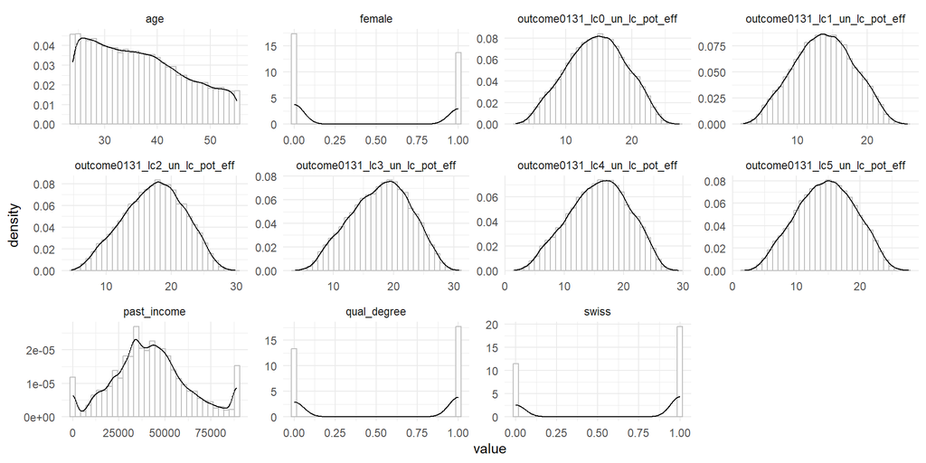

```r
df_plot <- training_df %>%
  select(all_of(c(VAR_POLSCORE_NAME, VAR_A_NAME_ORD, VAR_S_NAME_ORD))) %>%
  pivot_longer(
    cols = all_of(c(VAR_POLSCORE_NAME, VAR_A_NAME_ORD, VAR_S_NAME_ORD)),
    names_to = "variable",
    values_to = "value")
ggplot(
  df_plot, aes(x = value)) +
  geom_histogram(aes(y = after_stat(density)), colour = 'gray', bins=32, fill = "white") +
  geom_density(alpha = 0.5) +
  theme_minimal() +
  facet_wrap(~variable, scales='free')
```

# 2 MQ-Adjustment

Next, the MQ-adjustment is performed on both the features and the scores. We find that the MQ-adjustment approximately preserves the moments of the original variables but reduces the differences between the sensitive groups, as shown in the plots.

```r
# Run MQ adjustments
datasets <- list(training = training_df, evaluation = evaluation_df)
vars_list <- list(scores = VAR_POLSCORE_NAME, As = VAR_A_NAME_ORD)
scores_adjusted <- list()
for (data_name in names(datasets)) {
  df <- datasets[[data_name]]
  scores_adjusted[[data_name]] <- list()
  for (vars in names(vars_list)) {
    cols <- vars_list[[vars]]
    scores_adjusted[[data_name]][[vars]] <- mq_adjustment(
      vars = df[cols],
      sens = df[VAR_S_NAME_ORD],
      seed = SEED,
      ties.method = TIES_METHOD,
      quantile.type = 4
    )
    if(vars=="As"){
      scores_adjusted[[data_name]][[vars]]$vars_mq <- round(
        scores_adjusted[[data_name]][[vars]]$vars_mq)
    }
  }
}
# Extract results
scores_org <- training_df[VAR_POLSCORE_NAME]
scores_cdf <- scores_adjusted$training$scores$vars_cdf
scores_mq <- scores_adjusted$training$scores$vars_mq
As_org <- training_df[VAR_A_NAME_ORD]
As_cdf <- scores_adjusted$training$As$vars_cdf
As_mq <- scores_adjusted$training$As$vars_mq
sens_org <- training_df[VAR_S_NAME_ORD]
sens_comb_org <- training_df['sens_comb']

scores_org_out <- evaluation_df[VAR_POLSCORE_NAME]
scores_cdf_out <- scores_adjusted$evaluation$scores$vars_cdf
scores_mq_out <- scores_adjusted$evaluation$scores$vars_mq
As_org_out <- evaluation_df[VAR_A_NAME_ORD]
As_cdf_out <- scores_adjusted$evaluation$As$vars_cdf
As_mq_out <- scores_adjusted$evaluation$As$vars_mq
sens_org_out <- evaluation_df[VAR_S_NAME_ORD]
sens_comb_org_out <- evaluation_df['sens_comb']

# Put into one df
training_fair_df <- cbind(training_df, scores_cdf, scores_mq, As_cdf, As_mq)
evaluation_fair_df <- cbind(evaluation_df, scores_cdf_out, scores_mq_out, As_cdf_out, As_mq_out)

# Print means and standard deviations
table_scores <- data.frame(
  scores_mean = colMeans(training_df[VAR_POLSCORE_NAME]),
  scores_cdf_mean = colMeans(scores_cdf),
  scores_mq_mean = colMeans(scores_mq),
  scores_std = sqrt(diag(var(training_df[VAR_POLSCORE_NAME]))),
  scores_cdf_std = sqrt(diag(var(scores_cdf))),
  scores_mq_std = sqrt(diag(var(scores_mq))))
knitr::kable(
  table_scores , digits=2,
  caption="Means and standard deviations of scores before and after adjustment")
```

Means and standard deviations of scores before and after adjustment

|  | scores_mean | scores_cdf_mean | scores_mq_mean | scores_std | scores_cdf_std | scores_mq_std |
| --- | --- | --- | --- | --- | --- | --- |
| outcome0131_lc0_un_lc_pot_eff | 14.59 | 0.5 | 14.59 | 4.47 | 0.29 | 4.47 |
| outcome0131_lc1_un_lc_pot_eff | 13.76 | 0.5 | 13.76 | 4.24 | 0.29 | 4.24 |
| outcome0131_lc2_un_lc_pot_eff | 17.31 | 0.5 | 17.31 | 4.60 | 0.29 | 4.60 |
| outcome0131_lc3_un_lc_pot_eff | 17.88 | 0.5 | 17.88 | 4.89 | 0.29 | 4.89 |
| outcome0131_lc4_un_lc_pot_eff | 15.81 | 0.5 | 15.81 | 4.99 | 0.29 | 4.99 |
| outcome0131_lc5_un_lc_pot_eff | 14.67 | 0.5 | 14.67 | 4.54 | 0.29 | 4.55 |

```r
table_A <- data.frame(
    As_mean = colMeans(training_df[VAR_A_NAME_ORD]),
    As_cdf_mean = colMeans(As_cdf),
    As_mq_mean = colMeans(As_mq),
    As_std = sqrt(diag(var(training_df[VAR_A_NAME_ORD]))),
    As_cdf_std = sqrt(diag(var(As_cdf))),
    As_mq_std = sqrt(diag(var(As_mq))))
knitr::kable(
  table_A, digits=2,
  caption="Means and standard deviations of features before and after adjustment")
```

Means and standard deviations of features before and after adjustment

|  | As_mean | As_cdf_mean | As_mq_mean | As_std | As_cdf_std | As_mq_std |
| --- | --- | --- | --- | --- | --- | --- |
| age | 36.72 | 0.5 | 36.72 | 8.73 | 0.29 | 8.73 |
| past_income | 42352.23 | 0.5 | 42350.78 | 20364.41 | 0.29 | 20370.66 |
| qual_degree | 0.57 | 0.5 | 0.57 | 0.49 | 0.29 | 0.49 |

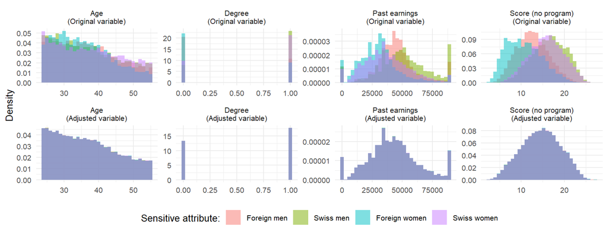

```r
# Plot distributions of scores and A for combinations of S
vars_to_plot <- c(VAR_POLSCORE_NAME, VAR_A_NAME_ORD)
vars_to_plot <- c(vars_to_plot, paste0(vars_to_plot, "_mq"))
vars_to_plot_sens <- c(vars_to_plot, 'sens_comb')

map_prog <- setNames(
  as.character(mappings[!is.na(mappings[VAR_D_NAME]),'X']),
  as.character(mappings[!is.na(mappings[VAR_D_NAME]), VAR_D_NAME]))

df_fullplot <- training_fair_df[, vars_to_plot_sens] %>% pivot_longer(all_of(vars_to_plot))
df_fullplot <- df_fullplot %>% mutate(
  type = if_else(str_ends(name, "_mq"), "Adjusted variable", "Original variable"),
  name = str_remove(name, "_mq"),
  program_number = str_match(name, paste0(OUTCOME, "_lc([0-9]+)_un_lc_pot_eff"))[, 2],
  name = if_else(!is.na(program_number), paste0("Score (", map_prog[program_number], ")"), name),
  name = if_else(name == "age", "Age", name),
  name = if_else(name == "past_income", "Past earnings", name),
  name = if_else(name == "qual_degree", "Degree", name)
)

df_fullplot <- df_fullplot %>% mutate(name_type = paste0(name, "\n(", type, ")"))
df_fullplot$type <- factor(df_fullplot$type, levels = c("Original variable", "Adjusted variable"))
levs <- c(
  sort(unique(df_fullplot$name_type[str_ends(df_fullplot$name_type, "\\(Original variable\\)")])),
  sort(unique(df_fullplot$name_type[str_ends(df_fullplot$name_type, "\\(Adjusted variable\\)")]))
)
df_fullplot$name_type <- factor(df_fullplot$name_type, levels = levs)

df_fullplot_main <- df_fullplot[is.na(df_fullplot$program_number) | df_fullplot$program_number == 0,]
df_fullplot_appendix <- df_fullplot[!is.na(df_fullplot$program_number) & df_fullplot$program_number > 0,]

histograms_cleaning <- ggplot(df_fullplot_main, aes(x = value, fill = sens_comb)) +
  geom_histogram(aes(y = after_stat(density)), alpha = 0.5, position = "identity", bins = 32) +
  labs(x=NULL, y = "Density", fill="Sensitive attribute:") +
  theme_minimal() +
  facet_wrap(~name_type, scales = "free", ncol = 4) +
  scale_y_continuous(labels = function(x) format(x, scientific = FALSE)) +
  scale_fill_discrete(
    labels = c("0_0" = "Foreign men", "1_0" = "Foreign women", "0_1" = "Swiss men", "1_1" = "Swiss women")) +
  theme(legend.position = "bottom", text = element_text(size = 10))
plot(histograms_cleaning)
```

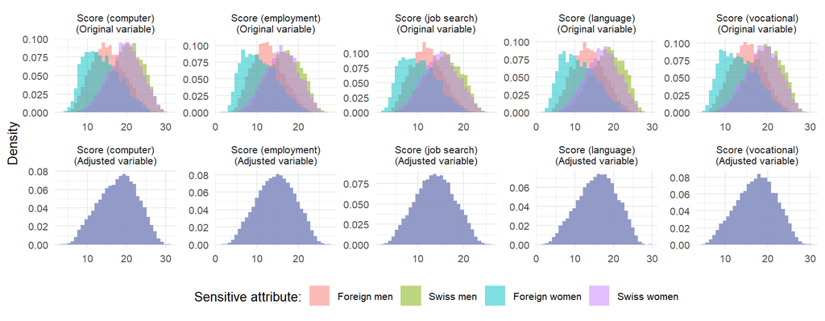

```r
histograms_cleaning_appendix <- ggplot(df_fullplot_appendix, aes(x = value, fill = sens_comb)) +
  geom_histogram(aes(y = after_stat(density)), alpha = 0.5, position = "identity", bins = 32) +
  labs(x=NULL, y = "Density", fill="Sensitive attribute:") +
  theme_minimal() +
  facet_wrap(~name_type, scales = "free", ncol = 5) +
  scale_y_continuous(labels = function(x) format(x, scientific = FALSE)) +
  scale_fill_discrete(
    labels = c("0_0" = "Foreign men", "1_0" = "Foreign women", "0_1" = "Swiss men", "1_1" = "Swiss women")) +
  theme(legend.position = "bottom", text = element_text(size = 10))
plot(histograms_cleaning_appendix)
```

# 3 Benchmark Policies

The analysis of the interplay between policy value, interpretability, and fairness starts by analyzing several benchmark policies. This includes the observed assignments and blackbox assignments according to the largest estimated score. By using the MQ-adjusted scores we can obtain a fairness-aware blackbox assignment. In addition, we can obtain a completely fair benchmark (according to our definition) which assigns all individuals to the same treatment.

```r
# Create functions for evaluation of assignments
# Policy value
compute_policyvalue <- function(Dstar, scores){
  outcomes <- mapply(function(idx, row) scores[
    row, idx], Dstar, seq_along(Dstar))
  return(mean(outcomes))
}
# Cramer's V
compute_cramerv <- function(Dstar, sens_comb){
  cramerV(table(Dstar, sens_comb))
}
# Chi2 test
compute_chi2 <- function(Dstar, sens_comb){
  round(chisq.test(table(Dstar, sens_comb))$p.value, 8)
}
# Bayes Factor
compute_BF <- function(Dstar, sens_comb){
  round(extractBF(contingencyTableBF(table(
    Dstar, sens_comb), sampleType = "indepMulti", fixedMargin = "cols"), onlybf=TRUE, logbf=TRUE), 8)
}
# Program frequencies
compute_prog_freq <- function(Dstar, levels=unique_D){
  prop.table(table(factor(Dstar, levels = unique_D)))
}


# Observed, blackbox and all-in-one assignments for training and evaluation sample
results_list <- list()
datasets <- list(training = training_fair_df, evaluation = evaluation_fair_df)
rows <- c("observed", "blackbox", "blackboxfair", "allin1")
cols <- c("Interpr.", "Policy value", "CramerV", "chi2 pval", "log(BF)", unique_D_ch)
for (set_name in names(datasets)) {
  df <- datasets[[set_name]]
  res <- matrix(NA, nrow = length(rows), ncol = length(cols),
                dimnames = list(rows, cols))
  # Observed assignment, policy value based on Y
  # (if variance required estimated scores could be used as well)
  D_obs <- df[[VAR_D_NAME]]
  res["observed", ] <- c(
    FALSE,
    mean(df[[OUTCOME]]),
    compute_cramerv(D_obs, df$sens_comb),
    compute_chi2(D_obs, df$sens_comb),
    compute_BF(D_obs, df$sens_comb),
    compute_prog_freq(D_obs)
  )
  # Blackbox assignment
  D_blackbox <- apply(df[VAR_POLSCORE_NAME], 1, which.max)
  res["blackbox", ] <- c(
    FALSE,
    compute_policyvalue(D_blackbox, df[VAR_POLSCORE_NAME]),
    compute_cramerv(D_blackbox, df$sens_comb),
    compute_chi2(D_blackbox, df$sens_comb),
    compute_BF(D_blackbox, df$sens_comb),
    compute_prog_freq(D_blackbox - 1)
  )
  # Fair blackbox assignment
  D_blackboxfair <- apply(df[paste0(VAR_POLSCORE_NAME,"_mq")], 1, which.max)
  res["blackboxfair", ] <- c(
    FALSE,
    compute_policyvalue(D_blackboxfair, df[VAR_POLSCORE_NAME]),
    compute_cramerv(D_blackboxfair, df$sens_comb),
    compute_chi2(D_blackboxfair, df$sens_comb),
    compute_BF(D_blackboxfair, df$sens_comb),
    compute_prog_freq(D_blackboxfair - 1)
  )
  # All-in-one benchmark
  best_program <- which.max(colMeans(df[VAR_POLSCORE_NAME]))
  D_allin1 <- rep(best_program, nrow(df))
  res["allin1", ] <- c(
    TRUE,
    compute_policyvalue(D_allin1, df[VAR_POLSCORE_NAME]),
    0,
    1,
    log(0),
    compute_prog_freq(D_allin1 - 1)
  )

  results_list[[set_name]] <- as.data.frame(res)
}

# Print results
knitr::kable(results_list[['training']], digits=3, caption="Training sample")
```

Training sample

|  | Interpr. | Policy value | CramerV | chi2 pval | log(BF) | 0 | 1 | 2 | 3 | 4 | 5 |
| --- | --- | --- | --- | --- | --- | --- | --- | --- | --- | --- | --- |
| observed | 0 | 14.486 | 0.075 | 0 | 120.510 | 0.746 | 0.196 | 0.013 | 0.014 | 0.021 | 0.010 |
| blackbox | 0 | 18.166 | 0.095 | 0 | 269.849 | 0.000 | 0.000 | 0.358 | 0.639 | 0.003 | 0.000 |
| blackboxfair | 0 | 18.149 | 0.031 | 0 | -10.522 | 0.000 | 0.000 | 0.364 | 0.631 | 0.003 | 0.001 |
| allin1 | 1 | 17.880 | 0.000 | 1 | -Inf | 0.000 | 0.000 | 0.000 | 1.000 | 0.000 | 0.000 |

```r
knitr::kable(results_list[['evaluation']], digits=3, caption="Evaluation sample")
```

Evaluation sample

|  | Interpr. | Policy value | CramerV | chi2 pval | log(BF) | 0 | 1 | 2 | 3 | 4 | 5 |
| --- | --- | --- | --- | --- | --- | --- | --- | --- | --- | --- | --- |
| observed | 0 | 14.528 | 0.065 | 0 | 18.118 | 0.745 | 0.197 | 0.013 | 0.014 | 0.021 | 0.009 |
| blackbox | 0 | 18.164 | 0.114 | 0 | 123.314 | 0.000 | 0.000 | 0.360 | 0.638 | 0.002 | 0.000 |
| blackboxfair | 0 | 18.144 | 0.029 | 0 | -24.776 | 0.000 | 0.000 | 0.365 | 0.629 | 0.005 | 0.001 |
| allin1 | 1 | 17.873 | 0.000 | 1 | -Inf | 0.000 | 0.000 | 0.000 | 1.000 | 0.000 | 0.000 |

# 4 Policy Trees

Next, we assess policy tree assignments for different adjustment scenarios:

- No adjustment ($S$ included in decision-relevant features)
- No adjustment ($S$ excluded from decision-relevant features)
- Adjustment of decision-relevant features
- Adjustment of scores
- Adjustment of decision-relevant features and scores

Note that policies involving adjustments of the decision-relevant features are no longer interpretable when using the standard policy trees.

```r
# Determine tree parameters besides depth:
# split.step:  To avoid lengthy computations, we determine a maximum of 100
# evaluation points for continuous variables. Hence, we set split.step = n/100
splitstep <- round(nrow(training_df)/100, 0)
# We set the minimum node size to 0.1*(n/depth):
minnodesize <- round(0.1*(nrow(training_df)/PT_DEPTH), 0)
# Determine tree type
if(PT_DEPTH == PT_SEARCH_DEPTH){
  tree_FUN <- function(
    X, Gamma, depth = PT_DEPTH, split.step = splitstep,
    min.node.size = minnodesize, verbose = TRUE){
    policy_tree(
      X, Gamma, depth = depth, split.step = split.step,
      min.node.size = min.node.size, verbose=verbose)
  }
}else{
  tree_FUN <- function(
    X, Gamma, depth = PT_DEPTH, search.depth = PT_SEARCH_DEPTH,
    split.step = splitstep, min.node.size = minnodesize, verbose = TRUE){
    hybrid_policy_tree(
      X, Gamma, depth = depth, search.depth = search.depth,
      split.step = split.step, min.node.size = min.node.size, verbose=verbose)
  }
}
# Run and evaluate policy trees for different adjustment scenarios
opt_tree_list <- list()
data_list <- list(
  pt_unadj_inclS = list(
    exp = TRUE, As = colnames(cbind(As_org, sens_org)), scores = colnames(scores_org)),
  pt_unadj_exclS = list(
    exp = TRUE, As = colnames(As_org), scores = colnames(scores_org)),
  pt_adjust_A = list(
    exp = FALSE, As = colnames(As_mq), scores = colnames(scores_org)),
  pt_adjust_score = list(
    exp = TRUE, As = colnames(As_org), scores = colnames(scores_mq)),
  pt_adjust_A_score = list(
    exp = FALSE, As = colnames(As_mq), scores = colnames(scores_mq)),
  pt_adjust_Acdf = list(
    exp = FALSE, As = colnames(As_cdf), scores = colnames(scores_org)),
  pt_adjust_Acdf_score = list(
    exp = FALSE, As = colnames(As_cdf), scores = colnames(scores_mq)))
for(set_name in names(data_list)) {
  opt_tree <- tree_FUN(
    training_fair_df[data_list[[set_name]]$As],
    training_fair_df[data_list[[set_name]]$scores])
  opt_tree_list[[set_name]] <- opt_tree
  Dstar_opt <- predict(opt_tree, training_fair_df[data_list[[set_name]]$As])
  Dstar_opt_out <- predict(opt_tree, evaluation_fair_df[data_list[[set_name]]$As])
  results_list$training[set_name, ] <- c(
    data_list[[set_name]]$exp,
    compute_policyvalue(Dstar_opt, scores_org),
    compute_cramerv(Dstar_opt, sens_comb_org$sens_comb),
    compute_chi2(Dstar_opt, sens_comb_org$sens_comb),
    compute_BF(Dstar_opt, sens_comb_org$sens_comb),
    compute_prog_freq(Dstar_opt - 1))
  results_list$evaluation[set_name, ] <- c(
    data_list[[set_name]]$exp,
    compute_policyvalue(Dstar_opt_out, scores_org_out),
    compute_cramerv(Dstar_opt_out, sens_comb_org_out$sens_comb),
    compute_chi2(Dstar_opt_out, sens_comb_org_out$sens_comb),
    compute_BF(Dstar_opt_out, sens_comb_org_out$sens_comb),
    compute_prog_freq(Dstar_opt_out - 1))
}
# Print results
knitr::kable(results_list[['training']], digits=3, caption="Training sample")
```

Training sample

|  | Interpr. | Policy value | CramerV | chi2 pval | log(BF) | 0 | 1 | 2 | 3 | 4 | 5 |
| --- | --- | --- | --- | --- | --- | --- | --- | --- | --- | --- | --- |
| observed | 0 | 14.486 | 0.075 | 0 | 120.510 | 0.746 | 0.196 | 0.013 | 0.014 | 0.021 | 0.010 |
| blackbox | 0 | 18.166 | 0.095 | 0 | 269.849 | 0.000 | 0.000 | 0.358 | 0.639 | 0.003 | 0.000 |
| blackboxfair | 0 | 18.149 | 0.031 | 0 | -10.522 | 0.000 | 0.000 | 0.364 | 0.631 | 0.003 | 0.001 |
| allin1 | 1 | 17.880 | 0.000 | 1 | -Inf | 0.000 | 0.000 | 0.000 | 1.000 | 0.000 | 0.000 |
| pt_unadj_inclS | 1 | 17.915 | 0.450 | 0 | 2281.428 | 0.000 | 0.000 | 0.199 | 0.801 | 0.000 | 0.000 |
| pt_unadj_exclS | 1 | 17.893 | 0.256 | 0 | 780.090 | 0.000 | 0.000 | 0.139 | 0.861 | 0.000 | 0.000 |
| pt_adjust_A | 0 | 17.896 | 0.083 | 0 | 67.227 | 0.000 | 0.000 | 0.130 | 0.870 | 0.000 | 0.000 |
| pt_adjust_score | 1 | 17.889 | 0.278 | 0 | 919.202 | 0.000 | 0.000 | 0.162 | 0.838 | 0.000 | 0.000 |
| pt_adjust_A_score | 0 | 17.891 | 0.088 | 0 | 78.424 | 0.000 | 0.000 | 0.187 | 0.813 | 0.000 | 0.000 |
| pt_adjust_Acdf | 0 | 17.896 | 0.080 | 0 | 62.356 | 0.000 | 0.000 | 0.137 | 0.863 | 0.000 | 0.000 |
| pt_adjust_Acdf_score | 0 | 17.892 | 0.076 | 0 | 54.861 | 0.000 | 0.000 | 0.186 | 0.814 | 0.000 | 0.000 |

```r
knitr::kable(results_list[['evaluation']], digits=3, caption="Evaluation sample")
```

Evaluation sample

|  | Interpr. | Policy value | CramerV | chi2 pval | log(BF) | 0 | 1 | 2 | 3 | 4 | 5 |
| --- | --- | --- | --- | --- | --- | --- | --- | --- | --- | --- | --- |
| observed | 0 | 14.528 | 0.065 | 0 | 18.118 | 0.745 | 0.197 | 0.013 | 0.014 | 0.021 | 0.009 |
| blackbox | 0 | 18.164 | 0.114 | 0 | 123.314 | 0.000 | 0.000 | 0.360 | 0.638 | 0.002 | 0.000 |
| blackboxfair | 0 | 18.144 | 0.029 | 0 | -24.776 | 0.000 | 0.000 | 0.365 | 0.629 | 0.005 | 0.001 |
| allin1 | 1 | 17.873 | 0.000 | 1 | -Inf | 0.000 | 0.000 | 0.000 | 1.000 | 0.000 | 0.000 |
| pt_unadj_inclS | 1 | 17.903 | 0.457 | 0 | 1174.750 | 0.000 | 0.000 | 0.202 | 0.798 | 0.000 | 0.000 |
| pt_unadj_exclS | 1 | 17.882 | 0.269 | 0 | 422.471 | 0.000 | 0.000 | 0.138 | 0.862 | 0.000 | 0.000 |
| pt_adjust_A | 0 | 17.884 | 0.089 | 0 | 35.379 | 0.000 | 0.000 | 0.124 | 0.876 | 0.000 | 0.000 |
| pt_adjust_score | 1 | 17.876 | 0.278 | 0 | 450.089 | 0.000 | 0.000 | 0.160 | 0.840 | 0.000 | 0.000 |
| pt_adjust_A_score | 0 | 17.881 | 0.090 | 0 | 36.355 | 0.000 | 0.000 | 0.181 | 0.819 | 0.000 | 0.000 |
| pt_adjust_Acdf | 0 | 17.884 | 0.088 | 0 | 34.569 | 0.000 | 0.000 | 0.131 | 0.869 | 0.000 | 0.000 |
| pt_adjust_Acdf_score | 0 | 17.882 | 0.080 | 0 | 25.829 | 0.000 | 0.000 | 0.183 | 0.817 | 0.000 | 0.000 |

```r
# Plot the trees
lab <- mappings[!is.na(mappings[VAR_D_NAME]), 'X']
plot(opt_tree_list[['pt_unadj_inclS']], leaf.labels=lab)
```

[interactive chart not shown]

```r
plot(opt_tree_list[['pt_unadj_exclS']], leaf.labels=lab)
```

[interactive chart not shown]

```r
plot(opt_tree_list[['pt_adjust_A']], leaf.labels=lab)
```

[interactive chart not shown]

```r
plot(opt_tree_list[['pt_adjust_score']], leaf.labels=lab)
```

[interactive chart not shown]

```r
plot(opt_tree_list[['pt_adjust_A_score']], leaf.labels=lab)
```

[interactive chart not shown]

# 5 Probabilistic Split Trees

To regain interpretability of policy trees with adjusted decision-relevant features, we can fit probabilistic split trees. We obtain one tree per sensitive group. In these trees there may occur probabilistic splits, meaning that at the splitting threshold, a certain proportion of individuals is randomly assigned to the left child node, while the remainder proceeds to the right child node. These probabilistic splits are necessary to break the dependence of the resulting assignments with the sensitive attributes.

```r
# Fit probabilistic split tree
data_list2 <- list(
  pst_adjust_A = list(exp = TRUE, adjust_scores = FALSE),
  pst_adjust_A_score = list(exp = TRUE, adjust_scores = TRUE))
for(set_name in names(data_list2)) {
  opt_tree <- prob_split_tree(
    As_org,
    scores_org,
    sens_org,
    adjust_scores=data_list2[[set_name]]$adjust_scores,
    seed=SEED,
    ties.method=TIES_METHOD,
    depth=PT_DEPTH,
    search.depth=PT_SEARCH_DEPTH,
    split.step=splitstep,
    min.node.size=minnodesize)
  opt_tree_list[[set_name]] <- opt_tree
  Dstar_opt <- predict(opt_tree, As_org, sens_org, seed=SEED)
  Dstar_opt_out <- predict(opt_tree, As_org_out, sens_org_out, seed=SEED)
  results_list$training[set_name, ] <- c(
    data_list2[[set_name]]$exp,
    compute_policyvalue(Dstar_opt, scores_org),
    compute_cramerv(Dstar_opt, sens_comb_org$sens_comb),
    compute_chi2(Dstar_opt, sens_comb_org$sens_comb),
    compute_BF(Dstar_opt, sens_comb_org$sens_comb),
    compute_prog_freq(Dstar_opt - 1))
  results_list$evaluation[set_name, ] <- c(
    data_list2[[set_name]]$exp,
    compute_policyvalue(Dstar_opt_out, scores_org_out),
    compute_cramerv(Dstar_opt_out, sens_comb_org_out$sens_comb),
    compute_chi2(Dstar_opt_out, sens_comb_org_out$sens_comb),
    compute_BF(Dstar_opt_out, sens_comb_org_out$sens_comb),
    compute_prog_freq(Dstar_opt_out - 1))
}
# Print results
knitr::kable(results_list[['training']], digits=3, caption="Training sample")
```

Training sample

|  | Interpr. | Policy value | CramerV | chi2 pval | log(BF) | 0 | 1 | 2 | 3 | 4 | 5 |
| --- | --- | --- | --- | --- | --- | --- | --- | --- | --- | --- | --- |
| observed | 0 | 14.486 | 0.075 | 0 | 120.510 | 0.746 | 0.196 | 0.013 | 0.014 | 0.021 | 0.010 |
| blackbox | 0 | 18.166 | 0.095 | 0 | 269.849 | 0.000 | 0.000 | 0.358 | 0.639 | 0.003 | 0.000 |
| blackboxfair | 0 | 18.149 | 0.031 | 0 | -10.522 | 0.000 | 0.000 | 0.364 | 0.631 | 0.003 | 0.001 |
| allin1 | 1 | 17.880 | 0.000 | 1 | -Inf | 0.000 | 0.000 | 0.000 | 1.000 | 0.000 | 0.000 |
| pt_unadj_inclS | 1 | 17.915 | 0.450 | 0 | 2281.428 | 0.000 | 0.000 | 0.199 | 0.801 | 0.000 | 0.000 |
| pt_unadj_exclS | 1 | 17.893 | 0.256 | 0 | 780.090 | 0.000 | 0.000 | 0.139 | 0.861 | 0.000 | 0.000 |
| pt_adjust_A | 0 | 17.896 | 0.083 | 0 | 67.227 | 0.000 | 0.000 | 0.130 | 0.870 | 0.000 | 0.000 |
| pt_adjust_score | 1 | 17.889 | 0.278 | 0 | 919.202 | 0.000 | 0.000 | 0.162 | 0.838 | 0.000 | 0.000 |
| pt_adjust_A_score | 0 | 17.891 | 0.088 | 0 | 78.424 | 0.000 | 0.000 | 0.187 | 0.813 | 0.000 | 0.000 |
| pt_adjust_Acdf | 0 | 17.896 | 0.080 | 0 | 62.356 | 0.000 | 0.000 | 0.137 | 0.863 | 0.000 | 0.000 |
| pt_adjust_Acdf_score | 0 | 17.892 | 0.076 | 0 | 54.861 | 0.000 | 0.000 | 0.186 | 0.814 | 0.000 | 0.000 |
| pst_adjust_A | 1 | 17.894 | 0.081 | 0 | 63.422 | 0.000 | 0.000 | 0.136 | 0.864 | 0.000 | 0.000 |
| pst_adjust_A_score | 1 | 17.891 | 0.075 | 0 | 54.094 | 0.000 | 0.000 | 0.185 | 0.815 | 0.000 | 0.000 |

```r
knitr::kable(results_list[['evaluation']], digits=3, caption="Evaluation sample")
```

Evaluation sample

|  | Interpr. | Policy value | CramerV | chi2 pval | log(BF) | 0 | 1 | 2 | 3 | 4 | 5 |
| --- | --- | --- | --- | --- | --- | --- | --- | --- | --- | --- | --- |
| observed | 0 | 14.528 | 0.065 | 0 | 18.118 | 0.745 | 0.197 | 0.013 | 0.014 | 0.021 | 0.009 |
| blackbox | 0 | 18.164 | 0.114 | 0 | 123.314 | 0.000 | 0.000 | 0.360 | 0.638 | 0.002 | 0.000 |
| blackboxfair | 0 | 18.144 | 0.029 | 0 | -24.776 | 0.000 | 0.000 | 0.365 | 0.629 | 0.005 | 0.001 |
| allin1 | 1 | 17.873 | 0.000 | 1 | -Inf | 0.000 | 0.000 | 0.000 | 1.000 | 0.000 | 0.000 |
| pt_unadj_inclS | 1 | 17.903 | 0.457 | 0 | 1174.750 | 0.000 | 0.000 | 0.202 | 0.798 | 0.000 | 0.000 |
| pt_unadj_exclS | 1 | 17.882 | 0.269 | 0 | 422.471 | 0.000 | 0.000 | 0.138 | 0.862 | 0.000 | 0.000 |
| pt_adjust_A | 0 | 17.884 | 0.089 | 0 | 35.379 | 0.000 | 0.000 | 0.124 | 0.876 | 0.000 | 0.000 |
| pt_adjust_score | 1 | 17.876 | 0.278 | 0 | 450.089 | 0.000 | 0.000 | 0.160 | 0.840 | 0.000 | 0.000 |
| pt_adjust_A_score | 0 | 17.881 | 0.090 | 0 | 36.355 | 0.000 | 0.000 | 0.181 | 0.819 | 0.000 | 0.000 |
| pt_adjust_Acdf | 0 | 17.884 | 0.088 | 0 | 34.569 | 0.000 | 0.000 | 0.131 | 0.869 | 0.000 | 0.000 |
| pt_adjust_Acdf_score | 0 | 17.882 | 0.080 | 0 | 25.829 | 0.000 | 0.000 | 0.183 | 0.817 | 0.000 | 0.000 |
| pst_adjust_A | 1 | 17.884 | 0.087 | 0 | 33.111 | 0.000 | 0.000 | 0.130 | 0.870 | 0.000 | 0.000 |
| pst_adjust_A_score | 1 | 17.884 | 0.074 | 0 | 21.057 | 0.000 | 0.000 | 0.181 | 0.819 | 0.000 | 0.000 |

```r
# Plot the trees
plot(opt_tree_list[['pst_adjust_A']], sens_names=VAR_S_NAME_ORD, leaf.labels=lab)
```

[interactive chart not shown]

```r
plot(opt_tree_list[['pst_adjust_A_score']], sens_names=VAR_S_NAME_ORD, leaf.labels=lab)
```

[interactive chart not shown]

```r
# Combine to one tree by manually adjusting dot string
dot_string_total <- ""
j <- 0
for(i in names(opt_tree_list[['pst_adjust_A_score']])){
  j <- j + 1
  dot_string2 <- plot(opt_tree_list[['pst_adjust_A_score']][[i]], leaf.labels=lab)[["x"]][["diagram"]]
  dot_string2 <- gsub("\n(\\d)", paste0("\n",j,"\\1"), dot_string2)
  dot_string2 <- gsub("-> (\\d)", paste0("-> ",j,"\\1"), dot_string2)
  dot_string2 <- sub("digraph nodes { \n node [shape=box] ;\n", "", dot_string2, fixed = TRUE)
  dot_string2 <- sub("\n}", "", dot_string2, fixed = TRUE)
  dot_string2 <- gsub(
    "[labeldistance=2.5, labelangle=45, headlabel=\"True\"]", "", dot_string2, fixed = TRUE)
  dot_string2 <- gsub(
    "[labeldistance=2.5, labelangle=-45, headlabel=\"False\"]", "", dot_string2, fixed = TRUE)
  dot_string_total <- paste0(dot_string_total, dot_string2)
}
dot_string <- paste0("
      digraph combined {
        rankdir=LR;
        node [shape=box];
        top [label=\"female = 0\", shape=ellipse, style=filled, fillcolor=lightblue];
        top2 [label=\"swiss = 0\", shape=ellipse, style=filled, fillcolor=lightblue];
        top3 [label=\"swiss = 0\", shape=ellipse, style=filled, fillcolor=lightblue];
        ", dot_string_total, "
        top -> top2 [labeldistance=3, labelangle=-30, headlabel='True'];
        top -> top3 [labeldistance=3, labelangle=30, headlabel='False'];
        top2 -> ", 10, ";
        top2 -> ", 20, ";
        top3 -> ", 30, ";
        top3 -> ", 40, ";
      }
    ")
dot_string <- gsub("qual_degree", "degree", dot_string, fixed = TRUE)
dot_string <- gsub("past_income", "past earnings", dot_string, fixed = TRUE)
DiagrammeR::grViz(dot_string)
```

[interactive chart not shown]

# 6 Partial Adjustments

One may only partially adjust the variables to further analyse the interplay between policy value and fairness. This is achieved by a linear combination of adjusted and original variables for different weights between 0 and 1. The steps are as follows:

1. Get grid of weights from 0 to 1 by 0.1 steps
2. Get partially adjusted scores and partially adjusted decision-relevant features
3. Run policy trees
4. Compute policy value and fairness measures and plot

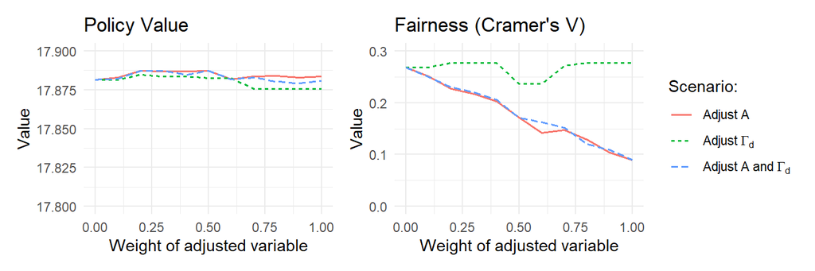

```r
# Define weights
weights <- seq(0,1,0.1)
inv_weights <- 1 - weights
As_weight <- mapply(
  function(w, iw) round(As_mq * w + As_org * iw, 0), weights, inv_weights, SIMPLIFY = FALSE)
As_weight_out <- mapply(
  function(w, iw) round(As_mq_out * w + As_org_out * iw, 0), weights, inv_weights, SIMPLIFY = FALSE)
scores_weight <- mapply(
  function(w, iw) scores_mq * w + scores_org * iw, weights, inv_weights, SIMPLIFY = FALSE)
As_org_list <- replicate(length(weights), As_org, simplify = FALSE)
As_org_out_list <- replicate(length(weights), As_org_out, simplify = FALSE)
scores_org_list <- replicate(length(weights), scores_org, simplify = FALSE)
# Setup scenarios
scenarios <- list(
  clean_As = list(As = As_weight, scores = scores_org_list, As_out = As_weight_out),
  clean_Scores = list(As = As_org_list, scores = scores_weight, As_out = As_org_out_list),
  clean_Scores_As = list(As = As_weight, scores = scores_weight, As_out = As_weight_out)
)
# Compute policy trees and policy value/fairness measures
rows <- list()
opt_tree_weight <- list()
for(scen in names(scenarios)){
  As_list <- scenarios[[scen]]$As
  Scores_list <- scenarios[[scen]]$scores
  As_out_list <- scenarios[[scen]]$As_out
  opt_tree_weight[[scen]] <- list()
  for(i in seq_along(weights)){
    opt_tree_weight[[scen]][[i]] <- tree_FUN(As_list[[i]], Scores_list[[i]])
    Dstar <- predict(opt_tree_weight[[scen]][[i]], As_out_list[[i]])
    rows[[length(rows) + 1]] <- data.frame(
      Weight = weights[i],
      Metric='Policy value',
      Scenario=scen,
      Value=compute_policyvalue(Dstar, scores_org_out))
    rows[[(length(rows) + 1)]] <- data.frame(
      Weight = weights[i],
      Metric='CramerV',
      Scenario=scen,
      Value=compute_cramerv(Dstar, sens_comb_org_out$sens_comb)[[1]])
  }
}
results_partial <- do.call(rbind, rows)
range_policyvalue <- results_partial %>% filter(Metric == "Policy value") %>%
  summarise(min_val = floor(min(Value) * 10) / 10, max_val = ceiling(
    max(Value) * 10) / 10)
range_CramerV <- results_partial %>% filter(Metric == "CramerV") %>%
  summarise(min_val = floor(min(Value) * 10) / 10, max_val = ceiling(
    max(Value) * 10) / 10)
# Plot
p1 <- ggplot(results_partial[results_partial$Metric == "Policy value", ], aes(
  x = Weight, y = Value, color = Scenario, linetype= Scenario)) +
  geom_line(linewidth=0.7) +
  labs(
    title = "Policy Value", x = "Weight of adjusted variable",
    color = "Scenario:", linetype= "Scenario:") +
  ylim(range_policyvalue$min_val, range_policyvalue$max_val) +
  theme_minimal() +
  scale_color_discrete(labels = c(
    expression(paste("Adjust ", A)), expression(paste("Adjust ", Gamma["d"])),
    expression(paste("Adjust ", A, " and ", Gamma["d"])))) +
  scale_linetype_discrete(labels = c(
    expression(paste("Adjust ", A)), expression(paste("Adjust ", Gamma["d"])),
    expression(paste("Adjust ", A, " and ", Gamma["d"]))))
p2 <- ggplot(results_partial[results_partial$Metric == "CramerV", ], aes(
  x = Weight, y = Value, color = Scenario, linetype= Scenario)) +
  geom_line(linewidth=0.7) +
  labs(
    title = "Fairness (Cramer's V)", x = "Weight of adjusted variable",
    color = "Scenario:", linetype= "Scenario:") +
  ylim(0, range_CramerV$max_val) +
  theme_minimal() +
  scale_color_discrete(labels = c(
    expression(paste("Adjust ", A)), expression(paste("Adjust ", Gamma["d"])),
    expression(paste("Adjust ", A, " and ", Gamma["d"])))) +
  scale_linetype_discrete(labels = c(
    expression(paste("Adjust ", A)), expression(paste("Adjust ", Gamma["d"])),
    expression(paste("Adjust ", A, " and ", Gamma["d"]))))
plot_combined <- (p1 + p2) + plot_layout(guides = "collect")
plot_combined
```

# 7 Winners and Losers

Finally, we can assess the winners and losers of the probabilistic tree assignments compared to assignments from the fairness-unaware policy tree (excluding $S$). The “winner” and “loser” groups are determined by kmeans clustering, with the number of clusters determined by the Silhouette score with the restriction of a minimum cluster size of 1% of the observations.

```r
# Prepare data
individual_policyvalue <- function(Dstar, scores) {
  scores[cbind(seq_along(Dstar), Dstar)]
}
data_df <- cbind(
  evaluation_df[, columns$X_ord[columns$X_ord > 0]],
  fastDummies::dummy_cols(
    data.frame(lapply(evaluation_df[, columns$X_unord[columns$X_unord > 0]], as.character)),
    remove_selected_columns = TRUE
  ),
  policyvalue_adjusted = individual_policyvalue(
    predict(tree = opt_tree_list[["pst_adjust_A_score"]], A = As_org_out, sens = sens_org_out),
    scores_org_out
  ),
  policyvalue_unadjusted = individual_policyvalue(
    predict(opt_tree_list[['pt_unadj_exclS']], As_org_out),
    scores_org_out
  )
)
# Compute the difference between actual and reference score.
data_df$policyvalue_diff <- data_df$policyvalue_adjusted - data_df$policyvalue_unadjusted
policyvalue_diff_matrix <- matrix(data_df$policyvalue_diff, ncol = 1)
# Determine optimal number of clusters using Silhouette score
dist_matrix <- stats::dist(policyvalue_diff_matrix)
min_cluster_size <- ceiling(nrow(data_df) / 100)
sil_width <- sapply(2:8, function(k){
  km <- kmeans(policyvalue_diff_matrix, centers = k, nstart = 10)
  ss <- silhouette(km$cluster, dist_matrix)
  if(min(km$size) > min_cluster_size){
    mean(ss[, 3])
  }else{
    0
  }
})
n_clusters <- which.max(sil_width) + 1
# Get clusters ordered by cluster mean
km <- kmeans(policyvalue_diff_matrix, centers = n_clusters, nstart = 10)
ordered_clusters <- order(km$centers)
cluster_map <- setNames(seq_along(ordered_clusters), ordered_clusters)
data_df$cluster_ids <- cluster_map[as.character(km$cluster)]
# Get variables means
df_grouped_means <- data_df %>%
  group_by(cluster_ids) %>%
  summarise(n = n(), across(where(is.numeric),\(x) mean(x, na.rm = TRUE)))  %>%
  pivot_longer(cols = -cluster_ids, names_to = "variable", values_to = "mean") %>%
  pivot_wider(names_from = cluster_ids, values_from = mean) %>%
  arrange(factor(variable, levels = c("policyvalue_diff", setdiff(variable, "policyvalue_diff")))) %>%
  mutate(across(where(is.numeric), round, 2))
# Generate meaningful cluster labels
generate_cluster_labels <- function(means) {
  labels <- character(length(means))
  gains <- means > 0
  losses <- means < 0
  zeros <- means == 0
  intensity_labels <- c("Strong", "Moderate", "Mild", "Slight")
  # Gains
  if(sum(gains) > 0){
    ranks <- rank(-means[gains], ties.method = "first")
    intensity <- if(sum(gains) > 1) paste(intensity_labels[seq_along(ranks)], "gain") else "gain"
    labels[gains] <- intensity[order(ranks)]
  }
  # Losses
  if(sum(losses) > 0){
    ranks <- rank(means[losses], ties.method = "first")
    intensity <- if(sum(losses) > 1) paste(intensity_labels[seq_along(ranks)], "loss") else "loss"
    labels[losses] <- intensity[order(ranks)]
  }
  # No change
  labels[zeros] <- "Small to no change"
  return(labels)
}
colnames(df_grouped_means) <- c("Variable", generate_cluster_labels(
  round(as.numeric(subset(df_grouped_means, variable == 'policyvalue_diff')[, -1]),2)))
# Print
knitr::kable(
  df_grouped_means,
  caption="Covariate means of k-means clusters")
```

Covariate means of k-means clusters

| Variable | Strong loss | Moderate loss | Small to no change | Moderate gain | Strong gain |
| --- | --- | --- | --- | --- | --- |
| policyvalue_diff | -2.07 | -0.90 | 0.00 | 0.84 | 1.82 |
| n | 135.00 | 268.00 | 11022.00 | 276.00 | 159.00 |
| female | 0.41 | 0.50 | 0.44 | 0.41 | 0.46 |
| swiss | 0.73 | 0.47 | 0.64 | 0.54 | 0.62 |
| age | 41.47 | 41.02 | 36.28 | 41.24 | 41.28 |
| canton_moth_tongue | 0.04 | 0.09 | 0.10 | 0.10 | 0.06 |
| cw_age | 43.89 | 42.47 | 44.15 | 44.26 | 47.19 |
| cw_cooperative | 0.56 | 0.50 | 0.49 | 0.42 | 0.35 |
| cw_educ_above_voc | 0.36 | 0.43 | 0.46 | 0.47 | 0.56 |
| cw_educ_tertiary | 0.38 | 0.21 | 0.20 | 0.15 | 0.13 |
| cw_female | 0.47 | 0.40 | 0.44 | 0.40 | 0.44 |
| cw_missing | 0.04 | 0.05 | 0.05 | 0.06 | 0.06 |
| cw_own_ue | 0.70 | 0.60 | 0.62 | 0.64 | 0.71 |
| cw_tenure | 5.24 | 5.37 | 5.53 | 5.71 | 5.98 |
| cw_voc_degree | 0.23 | 0.30 | 0.26 | 0.25 | 0.13 |
| emp_share_last_2yrs | 0.75 | 0.75 | 0.81 | 0.79 | 0.81 |
| emp_spells_5yrs | 1.53 | 1.16 | 1.18 | 1.31 | 1.12 |
| employability | 1.81 | 1.84 | 1.92 | 1.77 | 1.83 |
| foreigner_b | 0.09 | 0.20 | 0.13 | 0.16 | 0.09 |
| foreigner_c | 0.18 | 0.34 | 0.23 | 0.30 | 0.29 |
| gdp_pc | 0.58 | 0.54 | 0.52 | 0.49 | 0.49 |
| married | 0.50 | 0.64 | 0.46 | 0.63 | 0.60 |
| other_mother_tongue | 0.25 | 0.53 | 0.33 | 0.51 | 0.40 |
| past_income | 31609.26 | 31990.37 | 43069.82 | 32393.80 | 33957.55 |
| ue_cw_allocation1 | 0.63 | 0.56 | 0.59 | 0.52 | 0.54 |
| ue_cw_allocation2 | 0.55 | 0.47 | 0.51 | 0.43 | 0.38 |
| ue_cw_allocation3 | 0.04 | 0.03 | 0.04 | 0.05 | 0.03 |
| ue_cw_allocation4 | 0.08 | 0.11 | 0.08 | 0.12 | 0.05 |
| ue_cw_allocation5 | 0.09 | 0.17 | 0.12 | 0.13 | 0.13 |
| ue_cw_allocation6 | 0.10 | 0.14 | 0.09 | 0.12 | 0.06 |
| ue_spells_last_2yrs | 0.94 | 0.79 | 0.55 | 0.81 | 0.59 |
| unemp_rate | 4.15 | 3.63 | 3.51 | 3.25 | 3.36 |
| qual_degree | 0.38 | 0.19 | 0.59 | 0.23 | 0.21 |
| city_1 | 0.56 | 0.62 | 0.68 | 0.73 | 0.72 |
| city_2 | 0.16 | 0.13 | 0.12 | 0.12 | 0.15 |
| city_3 | 0.28 | 0.25 | 0.20 | 0.16 | 0.13 |
| prev_job_sec_cat_0 | 0.66 | 0.51 | 0.61 | 0.52 | 0.60 |
| prev_job_sec_cat_1 | 0.07 | 0.13 | 0.13 | 0.14 | 0.16 |
| prev_job_sec_cat_2 | 0.24 | 0.29 | 0.17 | 0.25 | 0.16 |
| prev_job_sec_cat_3 | 0.02 | 0.06 | 0.08 | 0.09 | 0.08 |
| prev_job_0 | 0.55 | 0.38 | 0.62 | 0.29 | 0.42 |
| prev_job_1 | 0.07 | 0.02 | 0.07 | 0.02 | 0.04 |
| prev_job_2 | 0.35 | 0.58 | 0.28 | 0.67 | 0.55 |
| prev_job_3 | 0.04 | 0.02 | 0.03 | 0.03 | 0.00 |
| qual_0 | 0.38 | 0.19 | 0.59 | 0.23 | 0.21 |
| qual_1 | 0.18 | 0.25 | 0.15 | 0.27 | 0.43 |
| qual_2 | 0.41 | 0.51 | 0.22 | 0.46 | 0.28 |
| qual_3 | 0.04 | 0.05 | 0.03 | 0.04 | 0.07 |
| policyvalue_adjusted | 14.14 | 13.33 | 18.15 | 14.40 | 15.87 |
| policyvalue_unadjusted | 16.21 | 14.23 | 18.15 | 13.56 | 14.05 |